# 01.scRNA-seq: fit P, NB, ZIP, ZINM models using simulated data

Simulate data following one of the four distritutions and estimate parameters in R.

Ming  
2021-11-21

This is the 2nd post of the ‘modelling gene expression with single cell data’ series.

Before jumping into real scRNA-seq data, in this post, I’d test [the four most frequently used statistical models in single cell gene expression modelling](https://www.nature.com/articles/s41588-021-00873-4) in R.

- P Possion model
- NB Negative Binomial model
- ZIP Zero-Inflated Poisson
- ZINB Zero-Inflated Negative Binomial

I’d simulate some data following certain probability distribution and use functions inside R to fit model and perform parameter estimation.

## Possion model

```r
# simulate 500 numbers following Possion model
set.seed(2049)
y <- rpois(n = 500, lambda = 4)
n <- 500
group <- sample(c(0,1), size = n, replace = TRUE)
y_sim <- rpois(n = n, lambda = exp(-2 + 0.5 * (group == 1)))
table(y_sim,group)
```

```
     group
y_sim   0   1
    0 208 210
    1  24  49
    2   2   7
```

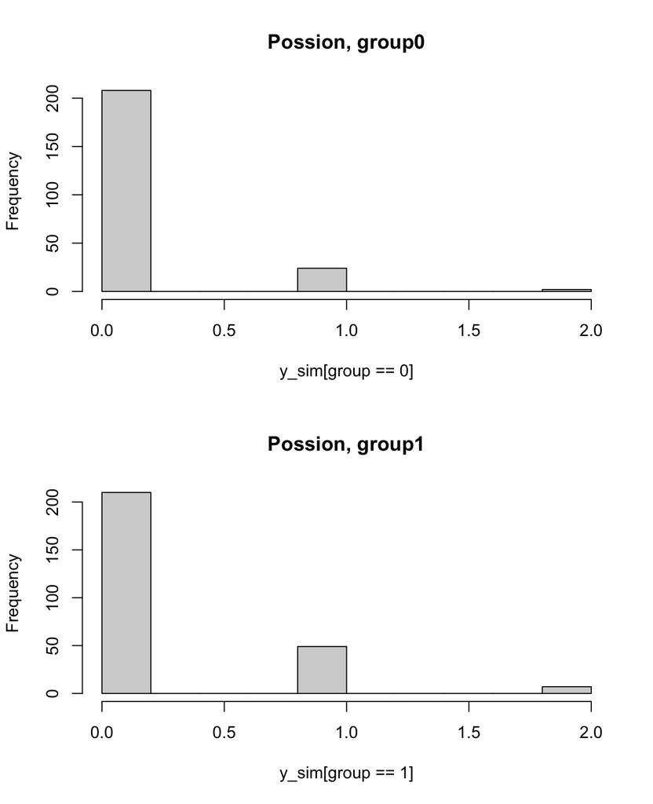

```r
par(mfrow=c(2,1))
hist(y_sim[group==0],main='Possion, group0')
hist(y_sim[group==1],main='Possion, group1')
```

```r
# fit model
m1 <- glm(y_sim ~ group, family = poisson(link='log') )
summary(m1)
```

```
Call:
glm(formula = y_sim ~ group, family = poisson(link = "log"))

Deviance Residuals:
    Min       1Q   Median       3Q      Max
-0.6883  -0.6883  -0.4892  -0.4892   2.7394

Coefficients:
            Estimate Std. Error z value Pr(>|z|)
(Intercept)  -2.1231     0.1890 -11.234  < 2e-16 ***
group         0.6828     0.2271   3.006  0.00265 **
---
Signif. codes:  0 '***' 0.001 '**' 0.01 '*' 0.05 '.' 0.1 ' ' 1

(Dispersion parameter for poisson family taken to be 1)

    Null deviance: 335.04  on 499  degrees of freedom
Residual deviance: 325.33  on 498  degrees of freedom
AIC: 498.86

Number of Fisher Scoring iterations: 6
```

```r
m0 <- update(m1, . ~ 1)
logLik(m0)
```

```
'log Lik.' -252.2794 (df=1)
```

```r
logLik(m1)
```

```
'log Lik.' -247.4284 (df=2)
```

```r
pchisq(2 * (logLik(m1) - logLik(m0)), df = 1, lower.tail = FALSE)
```

```
'log Lik.' 0.001840521 (df=2)
```

```r
#https://norcalbiostat.github.io/AppliedStatistics_notes/model-fit-criteria.html
AIC(m0,m1) #Smaller is better
```

```
   df      AIC
m0  1 506.5589
m1  2 498.8567
```

```r
BIC(m0,m1) #Smaller is better
```

```
   df      BIC
m0  1 510.7735
m1  2 507.2860
```

## Zero-inflated Possion model

Ref: https://stats.idre.ucla.edu/r/dae/zip/

A Zero-inflated Possion model has two component: inlfated 0 and a Possion distribution.

Thus, the probability of observing a 0 equals:

$$P(Y=0) = \pi + (1-\pi) *Poisson(0|lambda)$$

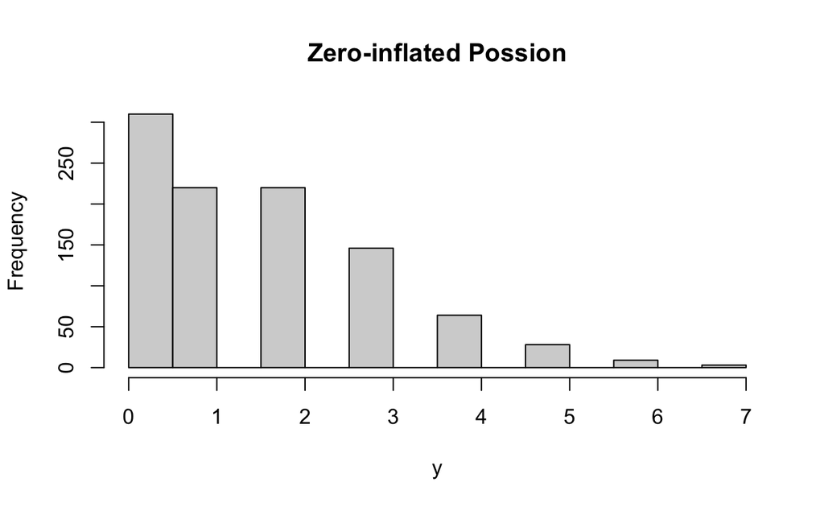

```r
#simulate data following zero-inflated Possion model
#https://stats.stackexchange.com/questions/189005/simulate-from-a-zero-inflated-poisson-distribution/189052
set.seed(2049)
n=1000;
pi=0.2;  #which means 1-pi=0.8 to be Poisson
lambda=2; #lambda parameter in the Possion distribution
y=ifelse(rbinom(n, size = 1, prob = 1-pi) == 0, 0, rpois(n, lambda = lambda))
group=sample(c('a','b'),n,replace = T)
simu.dat=data.frame(y=y,group=group)

par(mfrow=c(1,1))
hist(y,main='Zero-inflated Possion')
```

```r
# fit model
library(pscl)
m0 <- zeroinfl(y ~ 1, data = simu.dat)
x=summary(m0)
x
```

```
Call:
zeroinfl(formula = y ~ 1, data = simu.dat)

Pearson residuals:
    Min      1Q  Median      3Q     Max
-1.0657 -1.0657 -0.3865  0.4625  3.6888

Count model coefficients (poisson with log link):
            Estimate Std. Error z value Pr(>|z|)
(Intercept)  0.66813    0.03069   21.77   <2e-16 ***

Zero-inflation model coefficients (binomial with logit link):
            Estimate Std. Error z value Pr(>|z|)
(Intercept)  -1.4139     0.1196  -11.82   <2e-16 ***
---
Signif. codes:  0 '***' 0.001 '**' 0.01 '*' 0.05 '.' 0.1 ' ' 1

Number of iterations in BFGS optimization: 9
Log-likelihood: -1647 on 2 Df
```

```r
x$coefficients
```

```
$count
             Estimate Std. Error  z value      Pr(>|z|)
(Intercept) 0.6681281 0.03069023 21.77006 4.460646e-105

$zero
             Estimate Std. Error   z value     Pr(>|z|)
(Intercept) -1.413866  0.1196366 -11.81801 3.150731e-32
```

```r
exp(x$coefficients$count[1]) #possion, link.func=log
```

```
[1] 1.950583
```

```r
exp(x$coefficients$zero[1])/(1+exp(x$coefficients$zero[1])) # zero inflation which is not due to Poisson, link.func=logit
```

```
[1] 0.1956249
```

```r
# maximal likelihood
m1 <- update(m0, . ~ group)
logLik(m0)
```

```
'log Lik.' -1647.205 (df=2)
```

```r
logLik(m1)
```

```
'log Lik.' -1647.118 (df=4)
```

```r
pchisq(2 * (logLik(m1) - logLik(m0)), df = 2, lower.tail = FALSE) #m1 is not sig. better than m0. as in simulation, i just randomly assign numbers to two groups.
```

```
'log Lik.' 0.9168065 (df=4)
```

```r
AIC(m0,m1)
```

```
   df      AIC
m0  2 3298.410
m1  4 3302.236
```

```r
BIC(m0,m1)
```

```
   df      BIC
m0  2 3308.225
m1  4 3321.867
```

## Negative Binomial model

I used `rnbinom` function in `stats` R to simulate numbers.

Some [explanations](https://stat.ethz.ch/R-manual/R-devel/library/stats/html/NegBinomial.html) about this function:

> rnbinom(n, size, prob, mu)

> size: target for number of successful trials, or dispersion parameter (the shape parameter of the gamma mixing distribution). Must be strictly positive, need not be integer.

> An alternative parametrization (often used in ecology) is by the mean mu (see above), and size, the dispersion parameter, where prob = size/(size+mu). The variance is mu + mu^2/size in this parametrization.

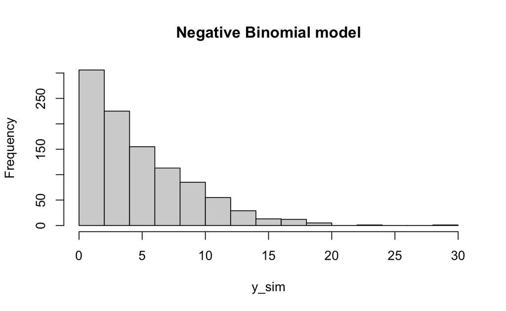

```r
# simulate negative binomial model
#https://data.library.virginia.edu/simulating-data-for-count-models/
set.seed(2049)
n <- 1000
y_sim <- rnbinom(n = n, mu =5, size = 2)

par(mfrow=c(1,1))
hist(y_sim,main='Negative Binomial model')
```

```r
m3 <- MASS::glm.nb(y_sim ~ 1)
summary(m3)
```

```
Call:
MASS::glm.nb(formula = y_sim ~ 1, init.theta = 2.096160936, link = log)

Deviance Residuals:
    Min       1Q   Median       3Q      Max
-2.2882  -0.9548  -0.3058   0.3843   3.0801

Coefficients:
            Estimate Std. Error z value Pr(>|z|)
(Intercept)  1.65096    0.02586   63.83   <2e-16 ***
---
Signif. codes:  0 '***' 0.001 '**' 0.01 '*' 0.05 '.' 0.1 ' ' 1

(Dispersion parameter for Negative Binomial(2.0962) family taken to be 1)

    Null deviance: 1119.5  on 999  degrees of freedom
Residual deviance: 1119.5  on 999  degrees of freedom
AIC: 5351.7

Number of Fisher Scoring iterations: 1

              Theta:  2.096
          Std. Err.:  0.138

 2 x log-likelihood:  -5347.740
```

```r
# mu: (link.function=log)
# Theta: the size parameter used in simulating data
exp(m3$coefficients)
```

```
(Intercept)
      5.212
```

```r
m3$theta
```

```
[1] 2.096161
```

```r
# add one covariate
set.seed(2049)
n <- 500
group <- sample(c(0,1), size = n, replace = TRUE)
y_sim <- rnbinom(n = n,
                 mu =exp(-2 + 0.7 * (group == 1)),
                 size = 0.05)
m1 <- MASS::glm.nb(y_sim ~ group)
summary(m1)
```

```
Call:
MASS::glm.nb(formula = y_sim ~ group, init.theta = 0.06272813776,
    link = log)

Deviance Residuals:
    Min       1Q   Median       3Q      Max
-0.4043  -0.4043  -0.3795  -0.3795   2.7589

Coefficients:
            Estimate Std. Error z value Pr(>|z|)
(Intercept)  -2.0022     0.2919  -6.859 6.93e-12 ***
group         0.2193     0.4267   0.514    0.607
---
Signif. codes:  0 '***' 0.001 '**' 0.01 '*' 0.05 '.' 0.1 ' ' 1

(Dispersion parameter for Negative Binomial(0.0627) family taken to be 1)

    Null deviance: 109.50  on 499  degrees of freedom
Residual deviance: 109.24  on 498  degrees of freedom
AIC: 367.49

Number of Fisher Scoring iterations: 1

              Theta:  0.0627
          Std. Err.:  0.0162

 2 x log-likelihood:  -361.4920
```

```r
m1$coefficients
```

```
(Intercept)       group
 -2.0022102   0.2192614
```

## Zero-inflated Negative Binomial model

A Zero-inflated Negative Binomial model has two component: inlfated 0 and a Negative Binomial distribution.

Thus, the probability of observing a 0 equals:

$$P(Y=0) = \pi + (1-\pi) *NB(0|mu,size)$$

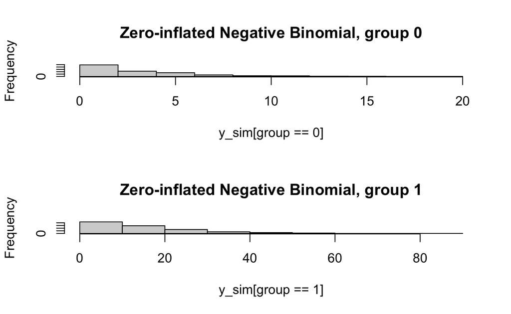

```r
# simulate zero-inflated negative binomial model
set.seed(2049)
n <- 1000
group <- sample(c(0,1), size = n, replace = TRUE)

pi=0.1; # pi=0.1, which means 1-pi=0.9 follows NB distribution
z <- rbinom(n = n, size = 1, prob = 1-pi)
# mean(z == 0)
y_sim <- ifelse(z == 0, 0,
                rnbinom(n = n,
                        mu = exp(1.3 + 1.5 * (group == 1)),
                        size = 2))

par(mfrow=c(2,1))
hist(y_sim[group==0],main='Zero-inflated Negative Binomial, group 0')
hist(y_sim[group==1],main='Zero-inflated Negative Binomial, group 1')
```

```r
m1=pscl::zeroinfl(y_sim~group,dist='negbin')
m1
```

```
Call:
pscl::zeroinfl(formula = y_sim ~ group, dist = "negbin")

Count model coefficients (negbin with log link):
(Intercept)        group
      1.308        1.489
Theta = 2.0097

Zero-inflation model coefficients (binomial with logit link):
(Intercept)        group
   -2.32531      0.09646
```

```r
x1=summary(m1)
x1
```

```
Call:
pscl::zeroinfl(formula = y_sim ~ group, dist = "negbin")

Pearson residuals:
    Min      1Q  Median      3Q     Max
-1.1733 -0.7251 -0.2222  0.4987  5.6434

Count model coefficients (negbin with log link):
            Estimate Std. Error z value Pr(>|z|)
(Intercept)  1.30820    0.04616  28.340   <2e-16 ***
group        1.48886    0.05808  25.636   <2e-16 ***
Log(theta)   0.69799    0.07424   9.402   <2e-16 ***

Zero-inflation model coefficients (binomial with logit link):
            Estimate Std. Error z value Pr(>|z|)
(Intercept) -2.32531    0.28934  -8.037 9.24e-16 ***
group        0.09646    0.32372   0.298    0.766
---
Signif. codes:  0 '***' 0.001 '**' 0.01 '*' 0.05 '.' 0.1 ' ' 1

Theta = 2.0097
Number of iterations in BFGS optimization: 11
Log-likelihood: -2983 on 5 Df
```

```r
# mu: (link.function=log)
# Theta: the size parameter used in simulating data

# mu in NB
x1$coefficients$count[1,1]
```

```
[1] 1.308202
```

```r
# theta, or size in NB
exp(x1$coefficients$count[3,1]) #size, same as theta
```

```
[1] 2.009717
```

```r
x1$theta
```

```
[1] 2.009717
```

```r
# prob of 0 in ZI not attributed to NB
g0=x1$coefficients$zero[1] #for group 0
g1=x1$coefficients$zero[1]+x1$coefficients$zero[2] #for group 1
exp(g0)/(1+exp(g0)) #prob
```

```
[1] 0.08904874
```

```r
exp(g1)/(1+exp(g1)) #prob
```

```
[1] 0.09718956
```